# Practical MachineLearning Project Report: Random Forest vs. Decision Tree Models

Byron Mattingly

18Apr2022

## Background

Using devices such as Jawbone Up, Nike FuelBand, and Fitbit it is now possible to collect a large amount of data about personal activity relatively inexpensively. These type of devices are part of the quantified self movement – a group of enthusiasts who take measurements about themselves regularly to improve their health, to find patterns in their behavior, or because they are tech geeks. One thing that people regularly do is quantify how much of a particular activity they do, but they rarely quantify how well they do it. In this project, your goal will be to use data from accelerometers on the belt, forearm, arm, and dumbell of 6 participants. They were asked to perform barbell lifts correctly and incorrectly in 5 different ways. More information is available from the website here: http://groupware.les.inf.puc-rio.br/har (see the section on the Weight Lifting Exercise Dataset).

## Data

The training data for this project are available here:

https://d396qusza40orc.cloudfront.net/predmachlearn/pml-training.csv

## The test data are available here:

https://d396qusza40orc.cloudfront.net/predmachlearn/pml-testing.csv

The data for this project come from this source: http://groupware.les.inf.puc-rio.br/har. If you use the document you create for this class for any purpose please cite them as they have been very generous in allowing their data to be used for this kind of assignment.

## What you should submit

The goal of your project is to predict the manner in which they did the exercise. This is the “classe” variable in the training set. You may use any of the other variables to predict with. You should create a report describing how you built your model, how you used cross validation, what you think the expected out of sample error is, and why you made the choices you did. You will also use your prediction model to predict 20 different test cases.

## Peer Review Portion

Your submission for the Peer Review portion should consist of a link to a Github repo with your R markdown and compiled HTML file describing your analysis. Please constrain the text of the writeup to < 2000 words and the number of figures to be less than 5. It will make it easier for the graders if you submit a repo with a gh-pages branch so the HTML page can be viewed online (and you always want to make it easy on graders).

## Initialization and Data cleaning

```r
# Libraries
library(ggplot2)
library(lattice)
library("caret")
library("randomForest")
library("rpart")
library("rpart.plot")
library("ranger")
# Set seed for reproducability
set.seed(9999)
```

The training_data and test_data were downloaded to the local directory and cleaned to eliminate observations with missing (“NA”, ““) and meaningless (”#DIV/0!“) values.

The training dataset contains 19622 observations and 160 variables, while the testing dataset contains 20 observations and 160 variables.

The `classe` variable in the training set is the outcome to predict.

```r
training_data <- read.csv("pml-training.csv", na.strings = c("NA", "#DIV/0!", ""))
dim(training_data)
```

```
## [1] 19622   160
```

```r
test_data     <- read.csv("pml-testing.csv",  na.strings = c("NA", "#DIV/0!", ""))
dim(test_data)
```

```
## [1]  20 160
```

## Data Preparation

Data containing more than 95% of their observations equal to “NA” are removed and filtered out.

```r
cleanColumnIndex    <- colSums(is.na(training_data))/nrow(training_data) < 0.95
clean_training_data <- training_data[,cleanColumnIndex]

# Verify NA removal
colSums(is.na(clean_training_data))/nrow(clean_training_data)
```

```
##                    X            user_name raw_timestamp_part_1
##                    0                    0                    0
## raw_timestamp_part_2       cvtd_timestamp           new_window
##                    0                    0                    0
##           num_window            roll_belt           pitch_belt
##                    0                    0                    0
##             yaw_belt     total_accel_belt         gyros_belt_x
##                    0                    0                    0
##         gyros_belt_y         gyros_belt_z         accel_belt_x
##                    0                    0                    0
##         accel_belt_y         accel_belt_z        magnet_belt_x
##                    0                    0                    0
##        magnet_belt_y        magnet_belt_z             roll_arm
##                    0                    0                    0
##            pitch_arm              yaw_arm      total_accel_arm
##                    0                    0                    0
##          gyros_arm_x          gyros_arm_y          gyros_arm_z
##                    0                    0                    0
##          accel_arm_x          accel_arm_y          accel_arm_z
##                    0                    0                    0
##         magnet_arm_x         magnet_arm_y         magnet_arm_z
##                    0                    0                    0
##        roll_dumbbell       pitch_dumbbell         yaw_dumbbell
##                    0                    0                    0
## total_accel_dumbbell     gyros_dumbbell_x     gyros_dumbbell_y
##                    0                    0                    0
##     gyros_dumbbell_z     accel_dumbbell_x     accel_dumbbell_y
##                    0                    0                    0
##     accel_dumbbell_z    magnet_dumbbell_x    magnet_dumbbell_y
##                    0                    0                    0
##    magnet_dumbbell_z         roll_forearm        pitch_forearm
##                    0                    0                    0
##          yaw_forearm  total_accel_forearm      gyros_forearm_x
##                    0                    0                    0
##      gyros_forearm_y      gyros_forearm_z      accel_forearm_x
##                    0                    0                    0
##      accel_forearm_y      accel_forearm_z     magnet_forearm_x
##                    0                    0                    0
##     magnet_forearm_y     magnet_forearm_z               classe
##                    0                    0                    0
```

```r
colSums(is.na(clean_training_data))
```

```
##                    X            user_name raw_timestamp_part_1
##                    0                    0                    0
## raw_timestamp_part_2       cvtd_timestamp           new_window
##                    0                    0                    0
##           num_window            roll_belt           pitch_belt
##                    0                    0                    0
##             yaw_belt     total_accel_belt         gyros_belt_x
##                    0                    0                    0
##         gyros_belt_y         gyros_belt_z         accel_belt_x
##                    0                    0                    0
##         accel_belt_y         accel_belt_z        magnet_belt_x
##                    0                    0                    0
##        magnet_belt_y        magnet_belt_z             roll_arm
##                    0                    0                    0
##            pitch_arm              yaw_arm      total_accel_arm
##                    0                    0                    0
##          gyros_arm_x          gyros_arm_y          gyros_arm_z
##                    0                    0                    0
##          accel_arm_x          accel_arm_y          accel_arm_z
##                    0                    0                    0
##         magnet_arm_x         magnet_arm_y         magnet_arm_z
##                    0                    0                    0
##        roll_dumbbell       pitch_dumbbell         yaw_dumbbell
##                    0                    0                    0
## total_accel_dumbbell     gyros_dumbbell_x     gyros_dumbbell_y
##                    0                    0                    0
##     gyros_dumbbell_z     accel_dumbbell_x     accel_dumbbell_y
##                    0                    0                    0
##     accel_dumbbell_z    magnet_dumbbell_x    magnet_dumbbell_y
##                    0                    0                    0
##    magnet_dumbbell_z         roll_forearm        pitch_forearm
##                    0                    0                    0
##          yaw_forearm  total_accel_forearm      gyros_forearm_x
##                    0                    0                    0
##      gyros_forearm_y      gyros_forearm_z      accel_forearm_x
##                    0                    0                    0
##      accel_forearm_y      accel_forearm_z     magnet_forearm_x
##                    0                    0                    0
##     magnet_forearm_y     magnet_forearm_z               classe
##                    0                    0                    0
```

Delete variables irrelevant to the model (columns 1 to 7):

```r
#   user_name
# , raw_timestamp_part_1
# , raw_timestamp_part_2
# , cvtd_timestamp
# , new_window
# , num_window

clean_training_data <- clean_training_data[,-c(1:7)]
clean_test_data     <- test_data[,-c(1:7)]
```

## Partition the training data into a training set (75%) and a cross validation set

```r
training_index <- createDataPartition(clean_training_data$classe, p=0.75)[[1]]
training_training_data <- clean_training_data[ training_index,]
training_crossval_data <- clean_training_data[-training_index,]
```

## and make a clean test dataset

```r
xNames          <- names(clean_training_data)
clean_test_data <- test_data[,xNames[1:52]]
```

## Prediction Model 1: Decision Tree ML Algorithm

Predict with decision tree and output the confusion matrix.

```r
decisionTreeModel      <- train(classe ~., method='rpart', data=training_training_data)
decisionTreePrediction <- predict(decisionTreeModel, training_crossval_data)
confusionMatrix(as.factor(training_crossval_data$classe), decisionTreePrediction)
```

```
## Confusion Matrix and Statistics
##
##           Reference
## Prediction    A    B    C    D    E
##          A 1264   24  104    0    3
##          B  434  303  212    0    0
##          C  397   31  427    0    0
##          D  370  141  293    0    0
##          E  119  125  245    0  412
##
## Overall Statistics
##
##                Accuracy : 0.4906
##                  95% CI : (0.4765, 0.5047)
##     No Information Rate : 0.5269
##     P-Value [Acc > NIR] : 1
##
##                   Kappa : 0.3336
##
##  Mcnemar's Test P-Value : NA
##
## Statistics by Class:
##
##                      Class: A Class: B Class: C Class: D Class: E
## Sensitivity            0.4892  0.48558  0.33333       NA  0.99277
## Specificity            0.9435  0.84907  0.88187   0.8361  0.89107
## Pos Pred Value         0.9061  0.31928  0.49942       NA  0.45727
## Neg Pred Value         0.6238  0.91884  0.78908       NA  0.99925
## Prevalence             0.5269  0.12724  0.26122   0.0000  0.08462
## Detection Rate         0.2577  0.06179  0.08707   0.0000  0.08401
## Detection Prevalence   0.2845  0.19352  0.17435   0.1639  0.18373
## Balanced Accuracy      0.7163  0.66732  0.60760       NA  0.94192
```

Plot the decision tree

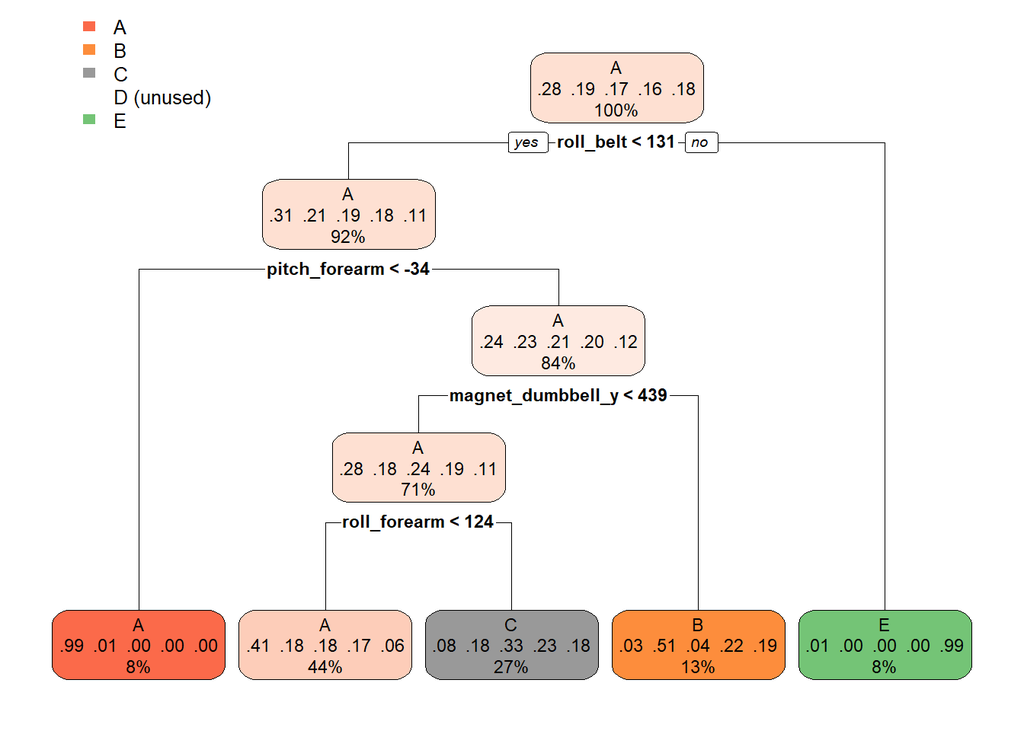

```r
rpart.plot(decisionTreeModel$finalModel)
```

## Prediction Model 2: Random Forest ML Algorithm

```r
randomForestModel      <- train(classe ~., method='rf', data=training_training_data, ntree=128)
randomForestPrediction <- predict(randomForestModel, training_crossval_data)
confusionMatrix(as.factor(training_crossval_data$classe), randomForestPrediction)
```

```
## Confusion Matrix and Statistics
##
##           Reference
## Prediction    A    B    C    D    E
##          A 1390    4    1    0    0
##          B    9  934    5    1    0
##          C    0    3  848    4    0
##          D    0    0    5  796    3
##          E    0    0    2    4  895
##
## Overall Statistics
##
##                Accuracy : 0.9916
##                  95% CI : (0.9887, 0.994)
##     No Information Rate : 0.2853
##     P-Value [Acc > NIR] : < 2.2e-16
##
##                   Kappa : 0.9894
##
##  Mcnemar's Test P-Value : NA
##
## Statistics by Class:
##
##                      Class: A Class: B Class: C Class: D Class: E
## Sensitivity            0.9936   0.9926   0.9849   0.9888   0.9967
## Specificity            0.9986   0.9962   0.9983   0.9980   0.9985
## Pos Pred Value         0.9964   0.9842   0.9918   0.9900   0.9933
## Neg Pred Value         0.9974   0.9982   0.9968   0.9978   0.9993
## Prevalence             0.2853   0.1919   0.1756   0.1642   0.1831
## Detection Rate         0.2834   0.1905   0.1729   0.1623   0.1825
## Detection Prevalence   0.2845   0.1935   0.1743   0.1639   0.1837
## Balanced Accuracy      0.9961   0.9944   0.9916   0.9934   0.9976
```

## Conclusion

Random Forest Model yields better results than the Decision Tree Model

## Prediction

Applying the Random Forest model to the original testing dataset to predict the test set

```r
predict(randomForestModel, clean_test_data)
```

```
##  [1] B A B A A E D B A A B C B A E E A B B B
## Levels: A B C D E
```

```r
## B A B A A E D B A A B C B A E E A B B B
## Levels: A B C D E
```